# Mixed effects models

April 28 2026

## Book chapters

- **The R Book (Crawley)**: Chapter 19 (Mixed-Effects Models). Key sections:
  - **Fixed and random effects**
  - **Pseudoreplication**
  - **Split-plot experiments**
  - **Nested designs**
- **An Introduction to Statistical Learning (ISLR)**:
  - *Note:* ISLR focuses mostly on standard i.i.d. predictive modeling. Mixed models go beyond the standard linear models discussed in ISLR Chapter 3, handling complex, non-independent data structures!

## Recap: The standard i.i.d. assumption

In standard Linear Regression and Generalized Linear Models (GLMs), a core assumption is that observations are **independent and identically distributed (i.i.d.)**.

\[ y_i \sim N(\beta_0 + \beta_1 x_i, \sigma^2) \]

- **Identically distributed**: Every observation \(y_i\) shares the same variance \(\sigma^2\) and follows the same relationship with \(x_i\).
- **Independent**: Knowing the residual (error) for observation \(y_1\) tells us absolutely nothing about the residual for observation \(y_2\).

## Why do standard i.i.d. models fail?

What if our data points are *grouped* or *structured*?

- Repeated measurements on the same patients over time.
- Plants growing in specific greenhouses.
- Grades giving by specific lecturers.
- Counties epidemiology data may be spatially correlated.
- Time series data may be temporally correlated.

If we measure the same patient 5 times, those 5 measurements are **not independent**. If the patient is naturally prone to higher blood pressure than average, all 5 of their measurements will have a positive residual.

## Why do standard i.i.d. models fail? (Cont.)

If we ignore this grouping structure and use a standard GLM:

1. The model assumes we have more independent information than we actually do (artificially inflated sample size).
2. Standard errors for our coefficients will be **underestimated**.
3. We will get **false positives** (p-values that are too small)!
4. Our estimates may be biased towards over-represented individuals’ measurements.

We need a model that explicitly accounts for this correlation structure.

## The Problem of Pseudoreplication: Example

- **Scenario**: You want to test the effect of a new diet on milk yields in a herd of cows.
- You have 10 cows in the herd.
- You measure the milk yield of each cow every day for 30 days.
- Is your sample size \(n=300\)?
- **NO.** Your true sample size of independent units is \(n=10\) (the cows). The 30 daily measurements are **pseudoreplicates**! The daily measurements from “Cow 1” are highly dependent on Cow 1’s baseline genetics and health.

## Mixed effects models

- Mixed effects models are (generalized) linear models with both **fixed** and **random** effects.
- Often fixed treatments are studied with *replications* on randomly selected objects/locations.
  - Replications in time: Repeated measurements.
  - Spatial replication: Observations from close locations.
  - Spatio-temporal correlations.
- **Main issue**: Dealing with dependence in data.
- Mixed effect models account for dependency in data. Ignoring dependence can lead to flawed conclusions!

## Fixed vs Random Effects (Crawley, R Book)

The distinction between fixed and random effects is crucial when building these models:

- **Fixed effects**: The levels of the factor are determined explicitly by the researcher. We are interested in the specific differences between these exact levels.
  - *Examples*: Drug vs Placebo, Male vs Female, High vs Low Temperature.
  - The conclusions drawn apply **only** to these specific levels.

## Fixed vs Random Effects (Cont.)

- **Random effects**: The levels are a random sample from a much larger population of possible levels. We are not interested in the specific differences between the levels we sampled, but in the general variation they represent.
  - *Examples*: Individual patient ID, specific plots of land, specific litters of animals.

## Random Intercept Only Model

Let’s start with the simplest mixed model: The **Random Intercept Model**.

This is equivalent to a One-Way ANOVA with random effects. We want to measure a continuous response across different random groups, without any specific fixed predictors (other than the global mean).

## The `rats` dataset

Let’s look at the `rats` dataset from the `BIAS.data` package.

We measure the Glycogen content in three different sections of rat livers. The rats themselves are randomly selected from a population.

```r
library(BIAS.data)
data(rats)
head(rats[,-2], 7)
```

```
##   Glycogen Rat Liver
## 1      131   1     1
## 2      130   1     1
## 3      131   1     2
## 4      125   1     2
## 5      136   1     3
## 6      142   1     3
## 7      150   2     1
```

## Structure of the `rats` dataset

- `Glycogen`: The continuous response variable.
- `Liver section`: The section of the liver (1, 2, or 3).
- `Rat`: The specific rat the liver came from. This is our **random effect**!

## Visualising the `rats` data

Let’s look at the variance *between* rats versus the variance *within* rats.

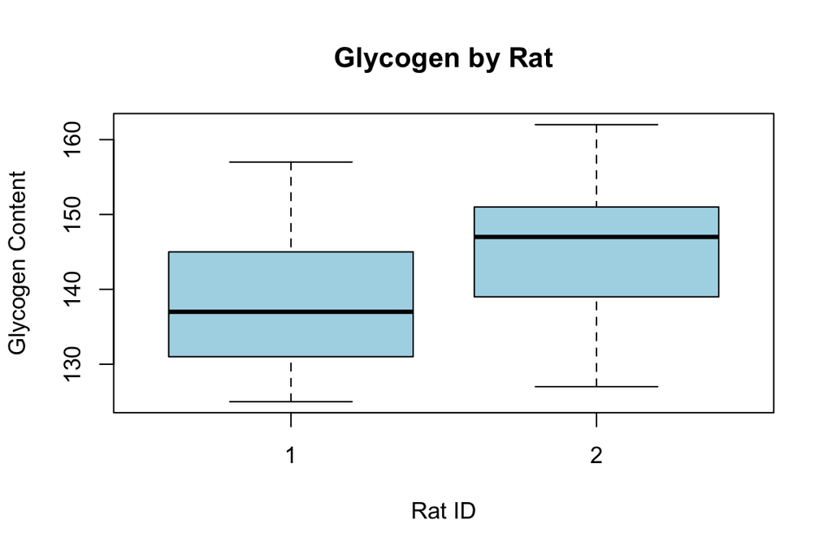

Some rats naturally have higher baseline glycogen than others!

## The Random Intercept Mathematical Model

To avoid complex matrix math, let’s write the model for a single observation using **scalar notation**:

Let \(y_{ij}\) be the glycogen content for the \(j\)-th measurement of the \(i\)-th rat.

\[ y_{ij} = \beta_0 + b_i + \epsilon_{ij} \]

Where:

- \(\beta_0\): The global intercept (average glycogen across all rats).
- \(b_i\): The random effect for rat \(i\). It represents how much rat \(i\)’s average deviates from the global average \(\beta_0\).
- \(\epsilon_{ij}\): The residual error for that specific measurement.

## Model Assumptions

\[ y_{ij} = \beta_0 + b_i + \epsilon_{ij} \]

What do we assume about the random terms?

1. **Random Effects**: \(b_i \sim N(0, \sigma^2_b)\) The rat-specific deviations follow a Normal distribution with variance \(\sigma^2_b\).
2. **Residuals**: \(\epsilon_{ij} \sim N(0, \sigma^2)\) The individual measurement errors follow a Normal distribution with variance \(\sigma^2\).
3. The random effects \(b_i\) and residuals \(\epsilon_{ij}\) are completely independent.

## Fitting the Random Intercept Model in R

We use the `lme()` function from the `nlme` package.

```r
library(nlme)
# We fit a random intercept (~ 1) for each Rat
rat_model <- lme(fixed = Glycogen ~ 1,
                 random = ~ 1 | Rat,
                 data = rats)
```

Notice the syntax:

- `fixed = Glycogen ~ 1`: The only fixed effect is the global intercept.
- `random = ~ 1 | Rat`: We allow the intercept (`1`) to vary randomly across each `Rat`.

## Full Summary: `rats` Model

```
## Linear mixed-effects model fit by REML
##   Data: rats
##        AIC      BIC    logLik
##   266.2975 270.9635 -130.1487
##
## Random effects:
##  Formula: ~1 | Rat
##         (Intercept) Residual
## StdDev:    4.266496  9.26216
##
## Fixed effects:  Glycogen ~ 1
##                Value Std.Error DF  t-value p-value
## (Intercept) 142.2222  3.388876 34 41.96737       0
##
## Standardized Within-Group Residuals:
##        Min         Q1        Med         Q3        Max
## -1.9334507 -0.6648481 -0.1658917  0.6068381  1.8854657
##
## Number of Observations: 36
## Number of Groups: 2
```

## Inference in Linear Mixed Models (High Level)

In standard regression, we use Maximum Likelihood Estimation (MLE) because we observe all the data. But in mixed models, the random effects (\(b_i\)) are **unobserved random variables**.

- We cannot just treat them as standard fixed parameters, or we’d overfit!
- Instead, the math **integrates them out**. We look at the “marginal likelihood” of the data given only the fixed effects and the variance parameters.
- For normal (Gaussian) data, this integration has a beautiful, exact mathematical solution.

## MLE vs REML

When we estimate the variances using standard Maximum Likelihood (ML), the estimates are slightly biased (too small), because ML doesn’t account for the degrees of freedom used up by estimating the fixed effects.

- Think of calculating sample variance: we divide by \(n-1\), not \(n\), to fix the bias!
- Mixed models use **REML (Restricted Maximum Likelihood)** instead of ML to get unbiased estimates of the variance components (\(\sigma^2_b\) and \(\sigma^2\)).
- **REML** is the default in R!
- **ML** should be preferred for model selection with AIC/BIC/LRT

## Explained Variance: The Intraclass Correlation Coefficient (ICC)

How much of the total variance in Glycogen is simply due to which rat we are looking at?

We calculate the **Intraclass Correlation Coefficient (ICC)**:

\[ \text{ICC} = \frac{\text{Variance Between Groups}}{\text{Total Variance}} = \frac{\sigma^2_b}{\sigma^2_b + \sigma^2} \]

The ICC tells us the proportion of total variance that is explained by our random grouping factor. It also represents the correlation between two measurements taken from the *same* rat!

## ICC Calculation for `rats`

From our output:

- \(\widehat\sigma_b = 4.27\)
- \(\widehat\sigma = 9.26\)

\[ \sigma^2_b = 4.27^2 \approx 18.23 \] \[ \widehat\sigma^2 = 9.26^2 \approx 85.75 \]

\[ \text{ICC} = \frac{18.23}{18.23 + 85.75} \approx 0.175 \]

Almost 17.5% of the variance in Glycogen is purely driven by biological differences between individual rats!

## Moving to Random Slopes: The `fertilizer` dataset

What if a predictor variable (like time) affects different groups differently? Let’s look at the `fertilizer` dataset.

```r
print(fertilizer[c(3:8,48:53),])
```

```
##    root week plant  treatment
## 3   7.0    6   ID1 fertilizer
## 4   8.1    8   ID1 fertilizer
## 5  10.0   10   ID1 fertilizer
## 6   2.0    2   ID2 fertilizer
## 7   3.5    4   ID2 fertilizer
## 8   5.5    6   ID2 fertilizer
## 48  4.1    6  ID10    control
## 49  6.2    8  ID10    control
## 50  8.8   10  ID10    control
## 51  1.2    2  ID11    control
## 52  2.4    4  ID11    control
## 53  4.1    6  ID11    control
```

## Visualising `fertilizer` trajectories

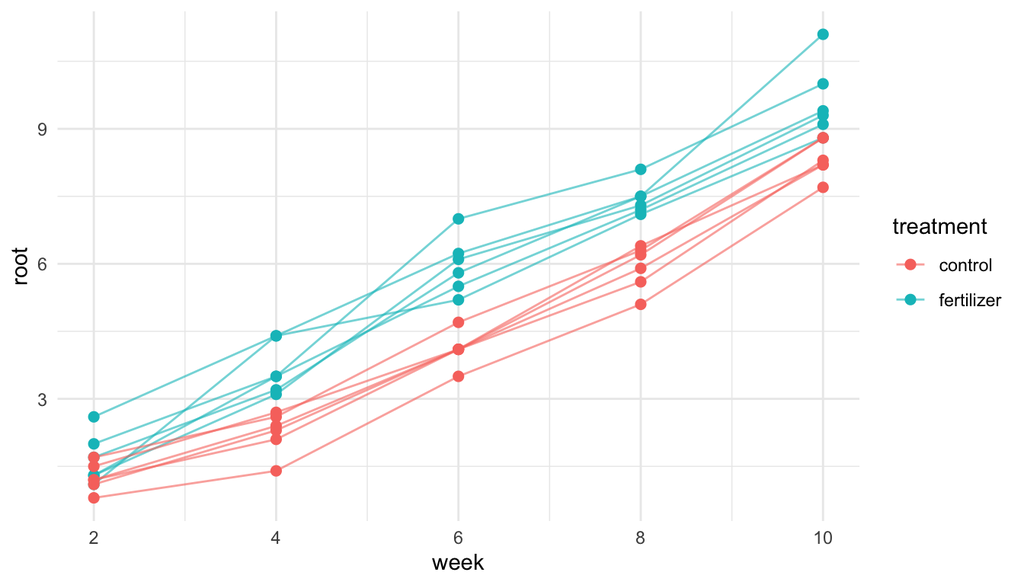

Look closely at the individual plants. They don’t just start at different lengths (different intercepts); their lines may have different steepness (different slopes)!

## Random intercept, random slope model

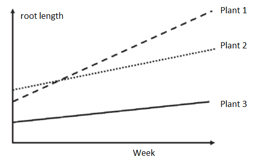

If we only used a random intercept, we would force all lines to be parallel. A **Random Slope** model allows each line to have its own angle!

## The Random Intercept + Random Slope Mathematical Model

Let \(y_{ij}\) be the root length for the \(i\)-th plant at week \(x_{ij}\).

\[ y_{ij} = (\beta_0 + b_{0i}) + \beta_1 \times treat_{ij} + b_{1i} \times week_{ij} + \epsilon_{ij} \]

Where:

- \(\beta_0\): Global average intercept at baseline.
- \(\beta_1\): Global treatment effect.
- \(b_{0i}\): How much plant \(i\)’s intercept deviates from the average.
- \(b_{1i}\): Individual plant \(i\)’s slopes.

## Fitting the Random Slope Model in R

```r
# Treatment is a fixed effect.
# Both Intercept and Week slope vary randomly by Plant.
res1 <- lme(fixed = root ~ treatment,
            random = ~ week | plant,
            data = fertilizer)
```

The syntax `random = ~ week | plant` tells R: “Allow the intercept AND the effect of `week` (slope) to vary randomly for each `plant`”.

## Full Summary: `fertilizer` Model

```
## Linear mixed-effects model fit by REML
##   Data: fertilizer
##        AIC      BIC    logLik
##   171.0236 183.3863 -79.51181
##
## Random effects:
##  Formula: ~week | plant
##  Structure: General positive-definite, Log-Cholesky parametrization
##             StdDev    Corr
## (Intercept) 2.8639832 (Intr)
## week        0.9369412 -0.999
## Residual    0.4966308
##
## Fixed effects:  root ~ treatment
##                        Value Std.Error DF   t-value p-value
## (Intercept)         1.760327 0.1438367 48 12.238371   0e+00
## treatmentfertilizer 1.039383 0.2034158 10  5.109644   5e-04
##  Correlation:
##                     (Intr)
## treatmentfertilizer -0.707
##
## Standardized Within-Group Residuals:
##        Min         Q1        Med         Q3        Max
## -1.9928118 -0.6586834 -0.1004301  0.6949714  2.0225381
##
## Number of Observations: 60
## Number of Groups: 12
```

## `summary(lme)`: Random Effects

Let’s examine the random effects standard deviations:

- `StdDev` for `(Intercept)`: \(\sigma_{b0} \approx 2.86\).
- `StdDev` for `week`: \(\sigma_{b1} \approx 0.94\).
- `Residual` standard error: \(\sigma \approx 0.50\).

This tells us there is substantial variation between plants in both their starting size AND their growth speed.

## ICC Calculation for `fertilizer`

Because we have a **random slope** for `week`, the variance between plants *changes over time*. Therefore, the ICC also changes over time!

At week 0 (the starting point), the variance between plants is just the variance of the intercept \(\sigma_{b0}^2\):

\[ \text{ICC}_{week=0} = \frac{\sigma_{b0}^2}{\sigma_{b0}^2 + \sigma^2} = \frac{2.86^2}{2.86^2 + 0.50^2} \approx 0.97 \]

An ICC of 97% means that at the beginning of the experiment, almost all the variation in root length is driven by the specific plant’s genetics/seed, rather than random noise!

## Residual Diagnostics for `fertilizer`

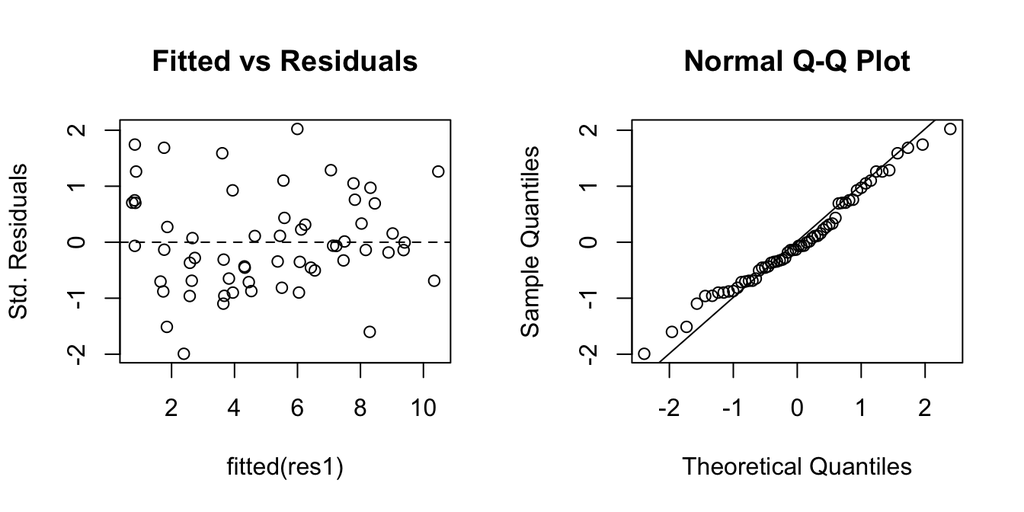

**What we want to see:** Points randomly scattered around the zero line in the left plot, and falling nicely on the diagonal line in the right plot.

Looks ok!

## Orthodont data.

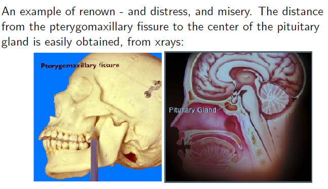

## Hierarchical (Nested) Design: Orthodont Data

Sometimes random effects are nested within each other.

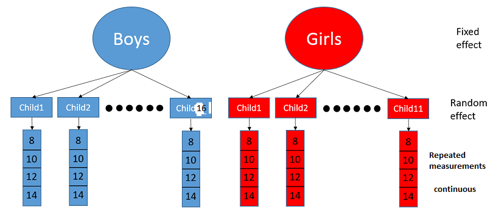

In the `Orthodont` dataset, we measure distance in children over time.

- `Child` is nested within `gender`.
- We have a fixed effect (`Sex`) and a random effect (`Subject` randomly chosen).

## Structure of `Orthodont`

```r
data(Orthodont)
head(Orthodont, 8)
```

```
## Grouped Data: distance ~ age | Subject
##   distance age Subject  Sex
## 1     26.0   8     M01 Male
## 2     25.0  10     M01 Male
## 3     29.0  12     M01 Male
## 4     31.0  14     M01 Male
## 5     21.5   8     M02 Male
## 6     22.5  10     M02 Male
## 7     23.0  12     M02 Male
## 8     26.5  14     M02 Male
```

We measure **`distance`** between some key points in the skull at different `age`s. `Subject` is the random effect.

## Visualising `Orthodont` Data

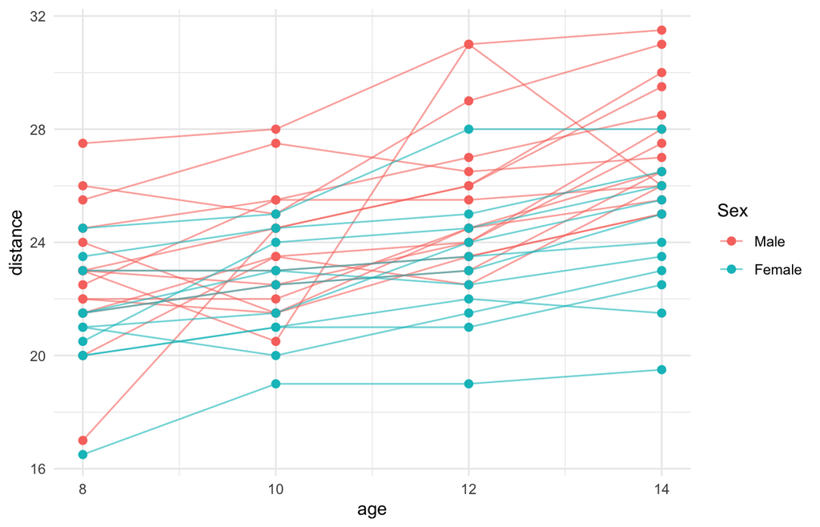

Distances differ between girls and boys over time, and variance appears to increase slightly.

## `Orthodont` Mathematical Model

Let \(y_{ij}\) be the distance for the \(i\)-th subject, at the \(j\)-th age. Let’s fit a random intercept model:

\[ y_{ij} = \beta_0 + \beta_1 \text{Age}_{ij} + \beta_2 \text{Sex}_{ij} + b_{i} + \epsilon_{ij} \]

- \(\beta_1\) and \(\beta_2\) are fixed effects.
- \(b_{i}\) is the random intercept for subject \(i\).

## Fitting `Orthodont` in R

```r
res3 <- lme(fixed = distance ~ age + Sex,
            random = ~ 1 | Subject,
            data = Orthodont, method = "ML")
```

## Full Summary: `Orthodont` Model

```
## Linear mixed-effects model fit by maximum likelihood
##   Data: Orthodont
##        AIC      BIC    logLik
##   444.8565 458.2671 -217.4282
##
## Random effects:
##  Formula: ~1 | Subject
##         (Intercept) Residual
## StdDev:    1.730079 1.422728
##
## Fixed effects:  distance ~ age + Sex
##                 Value Std.Error DF   t-value p-value
## (Intercept) 17.706713 0.8315459 80 21.293729  0.0000
## age          0.660185 0.0620929 80 10.632212  0.0000
## SexFemale   -2.321023 0.7430668 25 -3.123572  0.0045
##  Correlation:
##           (Intr) age
## age       -0.821
## SexFemale -0.364  0.000
##
## Standardized Within-Group Residuals:
##         Min          Q1         Med          Q3         Max
## -3.77682007 -0.55426744 -0.01578248  0.45835495  3.68124620
##
## Number of Observations: 108
## Number of Groups: 27
```

## ICC Calculation for `Orthodont`

We fit a random intercept model for the `Orthodont` data: \[ distance \sim age + Sex + (1|Subject) \]

From the `summary(lme)` output, we extract the variance components: - Subject variance (Between-child): \(\sigma_b^2 = 1.73^2 \approx 2.993\) - Residual variance (Within-child): \(\sigma^2 = 1.42^2 \approx 2.016\)

\[ \text{ICC} = \frac{\sigma_b^2}{\sigma_b^2 + \sigma^2} = \frac{2.993}{2.993 + 2.016} \approx 0.597 \]

Conclusion: **59.7%** of the variance in pituitary distance (after accounting for age and sex) is due to permanent biological differences between individual children.

## Adding random slope to `Orthodont`

```r
res4 <- lme(fixed = distance ~ age + Sex,
            random = ~ age | Subject,
            data = Orthodont, method = "ML")
```

\[ y_{ij} = \beta_0 + b_{0i} + (\beta_1 + b_{1i}) \text{Age}_{ij} + \beta_2 \text{Sex}_{ij} + \epsilon_{ij} \]

- \(\beta_1\) and \(\beta_2\) are fixed effects.
- \(b_{0i}\) is the random intercept for subject \(i\).
- \(b_{1i}\) is the deviation of random slopes for individuals for the population level parameter \(\beta_1\).

## Full Summary: `Orthodont` Model

```
## Linear mixed-effects model fit by maximum likelihood
##   Data: Orthodont
##        AIC      BIC    logLik
##   446.8352 465.6101 -216.4176
##
## Random effects:
##  Formula: ~age | Subject
##  Structure: General positive-definite, Log-Cholesky parametrization
##             StdDev    Corr
## (Intercept) 2.6447350 (Intr)
## age         0.2149243 -0.76
## Residual    1.3100397
##
## Fixed effects:  distance ~ age + Sex
##                 Value Std.Error DF   t-value p-value
## (Intercept) 17.635200 0.8769522 80 20.109647  0.0000
## age          0.660185 0.0709131 80  9.309772  0.0000
## SexFemale   -2.145491 0.7391991 25 -2.902453  0.0076
##  Correlation:
##           (Intr) age
## age       -0.843
## SexFemale -0.343  0.000
##
## Standardized Within-Group Residuals:
##         Min          Q1         Med          Q3         Max
## -3.16563246 -0.45463448  0.01446427  0.44559465  3.90045094
##
## Number of Observations: 108
## Number of Groups: 27
```

## Compare models

```r
anova.lme(res3,res4)
```

```
##      Model df      AIC      BIC    logLik   Test  L.Ratio p-value
## res3     1  5 444.8565 458.2671 -217.4282
## res4     2  7 446.8352 465.6101 -216.4176 1 vs 2 2.021324   0.364
```

## Population vs individual prediction

We can predict from the mixed model in two ways:  
- **Level 0 (Population):** uses only fixed effects.  
- **Level 1 (Individual):** adds subject-specific random effects.

```r
# Predict for selected observations
idx <- c(1, 10, 32, 40)

pred_pop <- predict(res4, level = 0)[idx]
pred_ind <- predict(res4, level = 1)[idx]
```

```
##     Subject age  Sex Actual   Pop   Ind
## M01     M01   8 Male   26.0 22.92 25.02
## M03     M03  10 Male   22.5 24.24 23.65
## M08     M08  14 Male   25.5 26.88 25.63
## M10     M10  14 Male   31.5 26.88 31.21
```

## Generalized Linear Mixed Models (GLMM) Intro

What if our response variable is **not continuous/normal**? For example, what if it’s count data (Poisson) or binary data (Binomial), but with random effects?

We use **Generalized Linear Mixed Models (GLMM)**! The most popular package in R for this is `lme4`, specifically the `glmer()` function.

## GLMM - Formulation

Like standard GLMs, responses \(y_{ij}\) are assumed to follow a distribution parameterized by the mean \(\mu_{ij}\) and dispersion \(\phi\): \[ y_{ij}\sim f(\mu_{ij}, \phi) \]

We model the expected value \(\mu_{ij} = E(y_{ij})\) using a link function \(g(\mu)\) while adding our random effects \(b_i\):

\[ g(\mu_{ij}) = \beta_0 + b_{0i} + (\beta_1 + b_{1i}) x_{ij} \]

- Fixed Effects: \(\beta_0\) (Intercept) and \(\beta_1\) (Slope)
- Random intercetpts: \(b_{0i}\) and slopes \(b_{1i}\)

## GLMM: Bovine Pleuropneumonia

Let’s use the `cbpp` dataset in `lme4`. We want to model the incidence of a disease (Binomial) over different periods, accounting for the random effect of the specific `herd`.

```r
library(lme4)
data(cbpp)
head(cbpp, 6)
```

```
##   herd incidence size period
## 1    1         2   14      1
## 2    1         3   12      2
## 3    1         4    9      3
## 4    1         0    5      4
## 5    2         3   22      1
## 6    2         1   18      2
```

## `cbpp` dataset structure

- `incidence`: The number of sick cows (Successes).
- `size`: Total cows in the herd (Trials).
- `period`: The time period (Fixed effect).
- `herd`: The specific herd (Random effect).

Because the incidence rate might be naturally higher in some herds than others due to environment, `herd` must be a random effect!

## Fitting the GLMM (`glmer`)

In `lme4`, we combine fixed and random effects in a single formula. Random effects are specified in parentheses: `(1 | herd)`.

```r
# Response is cbind(successes, failures)
glmm_mod <- glmer(cbind(incidence, size - incidence) ~
                  period + (1 | herd),
                  family = binomial(link="logit"),
                  data = cbpp)
```

- `(1 | herd)`: A random intercept for each herd.
- `family = binomial`: Tells R to use Binomial regression and a logit link!

## Full Summary: `glmer` Model

```
## Generalized linear mixed model fit by maximum likelihood (Laplace
##   Approximation) [glmerMod]
##  Family: binomial  ( logit )
## Formula: cbind(incidence, size - incidence) ~ period + (1 | herd)
##    Data: cbpp
##
##       AIC       BIC    logLik -2*log(L)  df.resid
##     194.1     204.2     -92.0     184.1        51
##
## Scaled residuals:
##     Min      1Q  Median      3Q     Max
## -2.3816 -0.7889 -0.2026  0.5142  2.8791
##
## Random effects:
##  Groups Name        Variance Std.Dev.
##  herd   (Intercept) 0.4123   0.6421
## Number of obs: 56, groups:  herd, 15
##
## Fixed effects:
##             Estimate Std. Error z value Pr(>|z|)
## (Intercept)  -1.3983     0.2312  -6.048 1.47e-09 ***
## period2      -0.9919     0.3032  -3.272 0.001068 **
## period3      -1.1282     0.3228  -3.495 0.000474 ***
## period4      -1.5797     0.4220  -3.743 0.000182 ***
## ---
## Signif. codes:  0 '***' 0.001 '**' 0.01 '*' 0.05 '.' 0.1 ' ' 1
##
## Correlation of Fixed Effects:
##         (Intr) perid2 perid3
## period2 -0.363
## period3 -0.340  0.280
## period4 -0.260  0.213  0.198
```

## Spatiotemporal Correlation Intro

Sometimes, the “random effect” structure isn’t just discrete groups (like `plant` or `herd`). Observations might be correlated **in continuous time** or **across 2D space**.

If measurements are taken sequentially in time, residuals are often auto-correlated (an observation is similar to the one immediately before it).

In `nlme`, we can add explicit **correlation structures** without necessarily using random effects, or in combination with them.

## Fitting Temporal Autocorrelation (AR1)

If we measure the same object over time at equal intervals, we can use an AR(1) process for the residuals. Let’s fit this to the `Orthodont` data.

```r
# Using lme to add an CAR(1) correlation structure across age
model_car1 <- lme(fixed = distance ~ age + Sex,
                 random = ~ 1 | Subject,
                 correlation = corCAR1(form = ~ 1 + age | Subject),
                 data = Orthodont,method = "ML")
```

## Full Summary: `corCAR1` Model

```
## Linear mixed-effects model fit by maximum likelihood
##   Data: Orthodont
##        AIC      BIC   logLik
##   446.7899 462.8827 -217.395
##
## Random effects:
##  Formula: ~1 | Subject
##         (Intercept) Residual
## StdDev:    1.716127 1.439108
##
## Correlation Structure: Continuous AR(1)
##  Formula: ~1 + age | Subject
##  Parameter estimate(s):
##       Phi
## 0.2091661
## Fixed effects:  distance ~ age + Sex
##                 Value Std.Error DF   t-value p-value
## (Intercept) 17.717687 0.8436907 80 21.000215  0.0000
## age          0.659601 0.0634392 80 10.397358  0.0000
## SexFemale   -2.325820 0.7428945 25 -3.130753  0.0044
##  Correlation:
##           (Intr) age
## age       -0.827
## SexFemale -0.359  0.000
##
## Standardized Within-Group Residuals:
##          Min           Q1          Med           Q3          Max
## -3.729131301 -0.551314026 -0.007755006  0.482340400  3.648881675
##
## Number of Observations: 108
## Number of Groups: 27
```

## Compare to no temporal effect res3

```r
anova.lme(res3,model_car1)
```

```
##            Model df      AIC      BIC    logLik   Test    L.Ratio p-value
## res3           1  5 444.8565 458.2671 -217.4282
## model_car1     2  6 446.7899 462.8827 -217.3949 1 vs 2 0.06658172  0.7964
```

## Visualizing Spatial Correlation

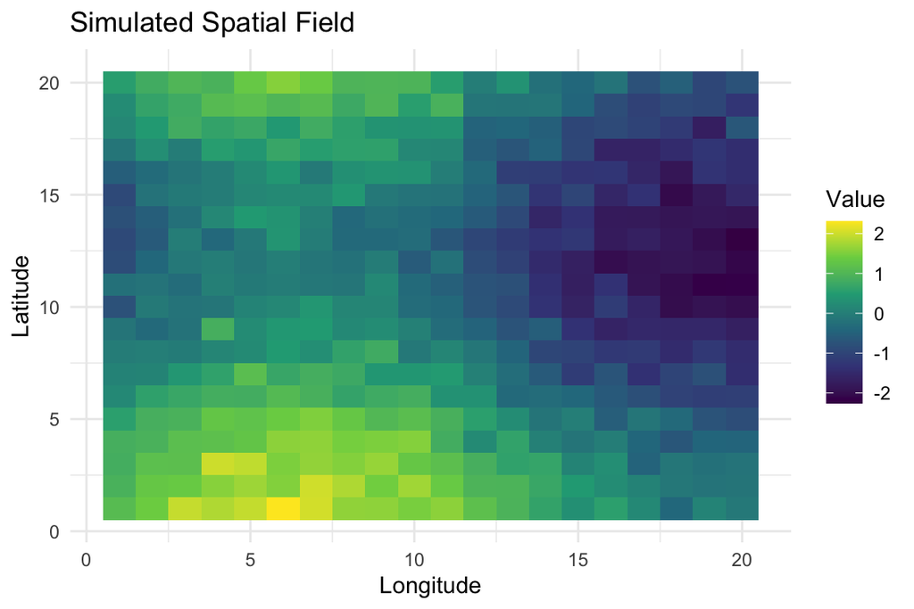

Values that are close together in 2D space are similar in color. A mixed model uses spatial correlation to properly model this!

## Spatial Correlation Intro

If data are collected across geographical coordinates \((x, y)\), points closer together are usually more similar.

**Intuition:** A measurement of soil pH at one spot is likely very similar to a measurement taken just 1 meter away!

We can model this spatial decay using exponential, spherical, or Gaussian correlation structures.

```r
# Example syntax for a spatial model in nlme
spatial_model <- gls(yield ~ fertilizer + temperature,
                     correlation = corExp(form = ~ x_coord + y_coord,
                                          nugget = TRUE),
                     data = spatial_data)
```

## STAT340: The Complete Journey

Over the past semester, we have built a powerful, flexible statistical toolkit. The course can be divided into distinct statistical domains:

- **Lectures 1:** Introduction
- **Lectures 2-5:** Linear Models & ANOVA (Continuous data)
- **Lectures 6-7:** Clustering & classification
- **Lectures 8-9:** Dimension Reduction (PCA, PCR, PLSR)
- **Lectures 10-11:** Generalized Linear Models (GLM)
- **Lecture 12:** Mixed Effects Models (LMM & GLMM)
- **Guest Lecture 1:** *Explainable Bayesian Deep Learning through Latent Binary Bayesian Neural Networks*
- **Guest Lecture:** *A Smooth Information Criterion for Selection and Fusion of Categorical Predictors*

## Back to the table

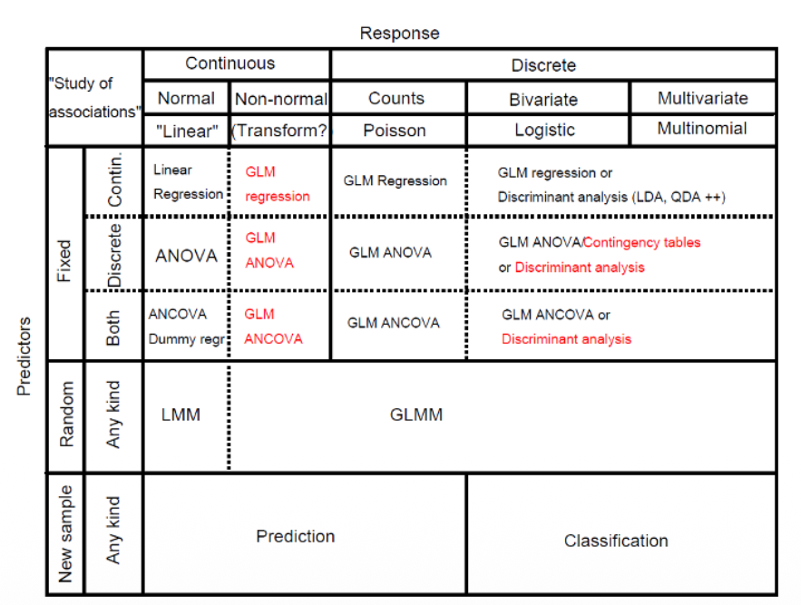

## Coverage

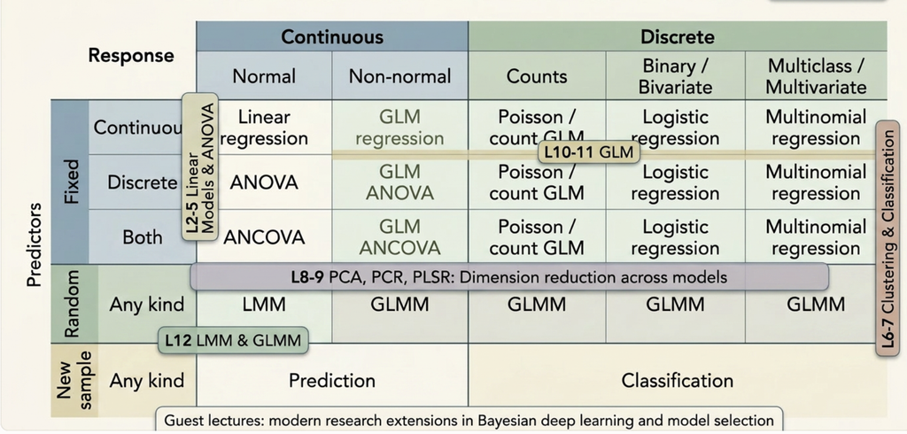

## The Golden Rule of Modeling

There is no single “correct” model.

1. **Check the Response:** Is it continuous, binary, or count? (Choose LM vs GLM link).
2. **Check the Predictors:** Are there too many correlated predictors? (Use PCA/PLSR/model selection).
3. **Check the Structure:** Are observations truly independent, or nested/grouped? (Choose fixed vs mixed effects).

**Thank you for a great semester in STAT340!**

**Good luck at the exam!**